# Introduction to Scikit-Learn: Machine Learning with Python

**Machine Learning Intro**

郭耀仁

## About Scikit-Learn

[Scikit-Learn](http://scikit-learn.org/stable/) is a Python package designed to give access to **well-known** machine learning algorithms within Python code, through a **clean, well-thought-out API**. It has been built by hundreds of contributors from around the world, and is used across industry and academia.

Scikit-Learn is built upon Python's [NumPy (Numerical Python)](http://numpy.org) and [SciPy (Scientific Python)](http://scipy.org) libraries, which enable efficient in-core numerical and scientific computation within Python.

## What is Machine Learning?

Machine Learning is about building programs with **tunable parameters** (typically an array of floating point values) that are adjusted automatically so as to improve their behavior by **adapting to previously seen data.**

[Tom Mitchell](http://www.cs.cmu.edu/~tom/)

> A computer program is said to learn from experience E with respect to some class of tasks T and performance measure P, if its performance at tasks in T, as measured by P, improves with experience E.

Machine Learning can be considered a subfield of **Artificial Intelligence** since those algorithms can be seen as building blocks to make computers learn to behave more intelligently by somehow **generalizing** rather that just storing and retrieving data items like a database system would do.

[figure not shown]

Source: [rapidminer](https://rapidminer.com/artificial-intelligence-machine-learning-deep-learning/)

## Machine Learning is

- Constructing/using algorithms that learn from data
- Performing better with more information
- Learning from previous solutions as experience

## Formulating Machine Learning

- input -> Function($f$) -> output
- input -> Estimated Function($\hat{f}$) -> predicted output

## Machine Learning Topics

- Supervised Learning
  - Classification
  - Regression
- Unsupervised Learning
  - Dimensionality Reduction
  - Clustering

## Machine Learning Topics in Depth

- Supervised Learning: Finding function $\hat{f}$ which can be used to assign a class or value to unseen observations given a set of labeled observations.
- Unsupervised Learning: Finding groups observation that are similar or using less vairiables to achieve similar predictability.

## Measuring performance

- Supervised Learning: Comparing real labels with predicted labels, great performance means predictions should be similar to real labels
- Unsupervised Learning: No real labels to compare

## Representation of Data in Scikit-learn

## Machine learning is about

- Creating models from data
- How data can be represented in order to be understood by the computer?

## Two-dimensional array or matrix

Most machine learning algorithms implemented in scikit-learn expect data to be stored in a **two-dimensional array or matrix**. The size of the array is expected to be `[m_samples, n_features]`

## m x n in general

- **m_samples:** The number of samples: each sample is an item to process (e.g. classify). A sample can be a document, a picture, a sound, a video, an astronomical object, a row in database or CSV file, or whatever you can describe with a fixed set of quantitative traits.
- **n_features:** The number of features or distinct traits that can be used to describe each item in a quantitative manner. Features are generally real-valued, but may be boolean or discrete-valued in some cases.

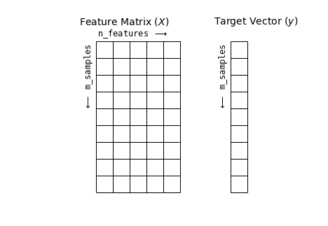

```python
plt.show()
```

## Simple Examples: Getting Started with Kaggle

We're going to take a look at the data hosted by Kaggle. Try extracting feature matrix and target vector from the following datasets:

- House Prices: Advanced Regression Techniques
- Titanic: Machine Learning from Disaster
- Digit Recognizer

## Installing Kaggle Module

```python
!pip install kaggle
```

## Creating New API Token

- Register / Log in Kaggle
- My Account
- Create New API Token

## Using Kaggle API on Google Colab

```
!mkdir /root/.kaggle
import json
token = {"username": "YOUR-USERNAME", "key": "YOUR-KEY"}
with open('/root/.kaggle/kaggle.json', 'w') as file:
    json.dump(token, file)
!chmod 600 /root/.kaggle/kaggle.json
```

```python
!kaggle datasets list
```

```
ref                                                          title                                                size  lastUpdated          downloadCount
-----------------------------------------------------------  --------------------------------------------------  -----  -------------------  -------------
ronitf/heart-disease-uci                                     Heart Disease UCI                                     3KB  2018-06-25 11:33:56          27773
karangadiya/fifa19                                           FIFA 19 complete player dataset                       2MB  2018-12-21 03:52:59          21716
iarunava/cell-images-for-detecting-malaria                   Malaria Cell Images Dataset                         337MB  2018-12-05 05:40:21           4379
bigquery/crypto-ethereum-classic                             Ethereum Classic Blockchain                          70GB  2019-03-20 23:21:25              0
jutrera/stanford-car-dataset-by-classes-folder               Stanford Car Dataset by classes folder                2GB  2018-07-02 07:35:45           2769
vjchoudhary7/customer-segmentation-tutorial-in-python        Mall Customer Segmentation Data                       2KB  2018-08-11 07:23:02           6845
russellyates88/suicide-rates-overview-1985-to-2016           Suicide Rates Overview 1985 to 2016                 396KB  2018-12-01 19:18:25          20324
rmisra/news-headlines-dataset-for-sarcasm-detection          News Headlines Dataset For Sarcasm Detection          2MB  2018-06-09 22:14:56           2556
lava18/google-play-store-apps                                Google Play Store Apps                                2MB  2019-02-03 13:55:47          48807
mohansacharya/graduate-admissions                            Graduate Admissions                                   9KB  2018-12-28 10:07:14          18344
jessicali9530/stanford-dogs-dataset                          Stanford Dogs Dataset                               735MB  2019-02-13 05:45:25           2480
anokas/kuzushiji                                             Kuzushiji-MNIST                                     318MB  2018-12-17 01:19:31            798
cityofLA/los-angeles-parking-citations                       Los Angeles Parking Citations                       257MB  2019-04-13 22:17:45           3032
noriuk/us-education-datasets-unification-project             U.S. Education Datasets: Unification Project         85MB  2019-03-02 18:41:52           3308
safegraph/visit-patterns-by-census-block-group               Consumer & Visitor Insights For Neighborhoods        66MB  2018-12-19 21:31:50           1303
safegraph/census-block-group-american-community-survey-data  Census Block Group American Community Survey Data     2GB  2018-12-22 00:29:56            707
jessicali9530/celeba-dataset                                 CelebFaces Attributes (CelebA) Dataset                1GB  2018-06-01 20:08:48           6412
pavansanagapati/urban-sound-classification                   Urban Sound Classification                            6GB  2018-06-16 13:44:36           2271
fivethirtyeight/fivethirtyeight-comic-characters-dataset     FiveThirtyEight Comic Characters Dataset            577KB  2019-03-26 15:01:15           2297
xvivancos/barcelona-data-sets                                Barcelona data sets                                   1MB  2018-12-13 14:16:53           3669
```

```python
!kaggle datasets list -s MNIST
```

```
ref                                title                         size  lastUpdated          downloadCount
---------------------------------  ---------------------------  -----  -------------------  -------------
daavoo/3d-mnist                    3D MNIST                     154MB  2016-11-09 18:53:12           2471
datamunge/sign-language-mnist      Sign Language MNIST           31MB  2017-10-20 15:09:18           5690
kmader/skin-cancer-mnist-ham10000  Skin Cancer MNIST: HAM10000    3GB  2018-09-20 20:36:13           7400
zalando-research/fashionmnist      Fashion MNIST                 69MB  2017-12-07 00:54:20          28597
kmader/colorectal-histology-mnist  Colorectal Histology MNIST   991MB  2018-09-19 14:20:49            927
vikramtiwari/mnist-numpy           mnist.npz                     11MB  2018-06-29 01:59:44            445
oddrationale/mnist-in-csv          MNIST in CSV                  15MB  2018-05-19 02:24:20           4936
pablotab/mnistpklgz                mnist.pkl.gz                  15MB  2017-11-20 15:02:57            298
miningjerry/mnist-for-tf           mnist for tf                  15MB  2017-05-16 09:50:29             63
joewkim/mnist-data                 mnist data                    11MB  2017-11-07 19:39:08             66
backalla/words-mnist               Words MNIST                   47MB  2018-06-06 09:34:28            114
mustafaali96/mnist                 mnist.                        11MB  2018-05-10 22:18:24             44
crawford/emnist                    EMNIST (Extended MNIST)        1GB  2017-12-20 17:42:58           5887
ashishguptajiit/handwritten-az     Handwritten A-Z               92MB  2018-01-26 15:44:12            527
kevinv/mnist1                      mnist1                        15MB  2017-11-30 16:55:58              4
jwjohnson314/notmnist              notMNIST                     226MB  2018-02-14 19:52:14            607
anokas/kuzushiji                   Kuzushiji-MNIST              318MB  2018-12-17 01:19:31            798
farhanhubble/multimnistm2nist      Multidigit MNIST(M2NIST)      17MB  2018-07-16 12:05:34            161
lianglirong/mnistnpz               mnist.npz                     11MB  2018-09-16 12:44:43              6
zsx242030/mnistplk                 mnist.plk                     11MB  2018-10-06 03:59:01              0
```

## House Prices: Advanced Regression Techniques

https://www.kaggle.com/c/house-prices-advanced-regression-techniques

```python
# Target Vector: SalePrice

train_url = "https://storage.googleapis.com/kaggle_datasets/House-Prices-Advanced-Regression-Techniques/train.csv"
```

```python
# Or using Kaggle-API
!kaggle competitions download -c house-prices-advanced-regression-techniques --force
```

```
Downloading sample_submission.csv to /Users/kuoyaojen/python-sklearn-cht
Downloading test.csv to /Users/kuoyaojen/python-sklearn-cht

Downloading train.csv to /Users/kuoyaojen/python-sklearn-cht

Downloading data_description.txt to /Users/kuoyaojen/python-sklearn-cht
```

## Titanic: Machine Learning from Disaster

https://www.kaggle.com/c/titanic

```python
# Target Vector: Survived

train_url = "https://storage.googleapis.com/kaggle_datasets/Titanic-Machine-Learning-from-Disaster/train.csv"
```

```python
# Or using Kaggle-API
!kaggle competitions download -c titanic --force
```

```
Downloading train.csv to /Users/kuoyaojen/python-sklearn-cht

Downloading test.csv to /Users/kuoyaojen/python-sklearn-cht
Downloading gender_submission.csv to /Users/kuoyaojen/python-sklearn-cht
```

## Digit Recognizer

https://www.kaggle.com/c/digit-recognizer

```python
# Target Vector: label

train_url = "https://storage.googleapis.com/kaggle_datasets/Digit-Recognizer/train.csv"
```

```python
# Or using Kaggle-API
!kaggle competitions download -c digit-recognizer --force
```

```
Downloading train.csv to /Users/kuoyaojen/python-sklearn-cht
Downloading test.csv to /Users/kuoyaojen/python-sklearn-cht

Downloading sample_submission.csv to /Users/kuoyaojen/python-sklearn-cht
```

## The Scikit-learn Estimator Object

Every algorithm is exposed in scikit-learn via an ''Estimator'' object.

```python
import numpy as np
import pandas as pd
import matplotlib.pyplot as plt
```

Estimator parameters: All the parameters of an estimator can be set when it is instantiated, and have suitable default values:

```python
from sklearn.linear_model import LinearRegression

model = LinearRegression()
print(model)
```

```
LinearRegression(copy_X=True, fit_intercept=True, n_jobs=None,
         normalize=False)
```

Estimated Model parameters: When data is fit with an estimator, parameters are estimated from the data at hand. All the estimated parameters are attributes of the estimator object ending by an underscore:

```python
train_url = "https://storage.googleapis.com/kaggle_datasets/House-Prices-Advanced-Regression-Techniques/train.csv"
train_df = pd.read_csv(train_url)
X_train = train_df["GrLivArea"].values
y_train = train_df["SalePrice"].values
reg = LinearRegression()
reg.fit(X_train, y_train)
print(reg.intercept_)
print(reg.coef_)
```

[output not shown]

```python
xfit = np.linspace(X_train.min() - 10, X_train.max() + 10, 100).reshape(-1, 1)
yfit = reg.predict(xfit)
plt.scatter(train_df["GrLivArea"], train_df["SalePrice"], label='train', s=3, color="#4286f4")
plt.plot(xfit, yfit, color="#f4a041", linewidth=2, label='thetas')
plt.legend()
```

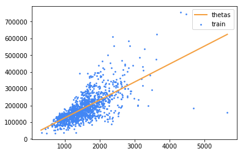

```python
plt.show()
```